# PMMD BiMODAL simulation

Chloe Yap

2025-07-24

# 1 Simulation set-up

- compare: clinical (monthly) vs mood (self-report weekly) vs wearables (continuous but say daily)

Questions of interest for the human study:

- can wearables data predict onset of depression defined using mood self-report and/or clinical impression?
- how much earlier can wearables data predict depression (vs mood self-report and clinical impression)?

Questions for this simulation:

1. Can we recover simulated lag time between wearables vs mood; wearables vs clinical?
2. Can we identify some threshold when wearables data from the individual can definitively diagnose “depression” vs a mood-based definition of depression (eg. 2 consecutive negative points taken 1 week apart) vs clinical-based definition of depression (eg. 2 consecutive negative points taken 1 month apart)

Simulation set-up:

- thresholds for mood: y > 0.5 = elevated mood vs y < -0.5 = depressed mood
- similar duration of episode between people
- variable amplitude between people
- similar lag between modalities across individuals
  - lag for mood vs wearable = 7 days behind
  - lag for clinical vs wearable = 14 days behind

Issues:

- assuming in this simulation that lag between modalities across individuals is similar (+/- some error). This may not be true in practice!!
- assuming that the lag “looks the same” across modalities
- **ground truth mood might be trickier to assess than on first glance … People who are manic often feel great. Also not necessarily able to assume that people are euthymic from the start of study collection. So what’s ground truth baseline/euthymia?**

# 2 Libraries

```r
library(rmarkdown)
library(tidyverse)
library(ggplot2)
library(lattice)
library(wesanderson)
library(ggformula)
library(lmtest)
library(gtsummary)

pal <- wes_palette("Zissou1", 5, type = "continuous")

set.seed(1234)
```

# 3 Simulation for Aim 1

## 3.1 Model as sine wave

- sine wave BUT better if could use function that stops oscillating after returning to 0 … Assuming that people have mania –> depression –> euthymia afterwards

### 3.1.1 Simulate wearables (daily sampling)

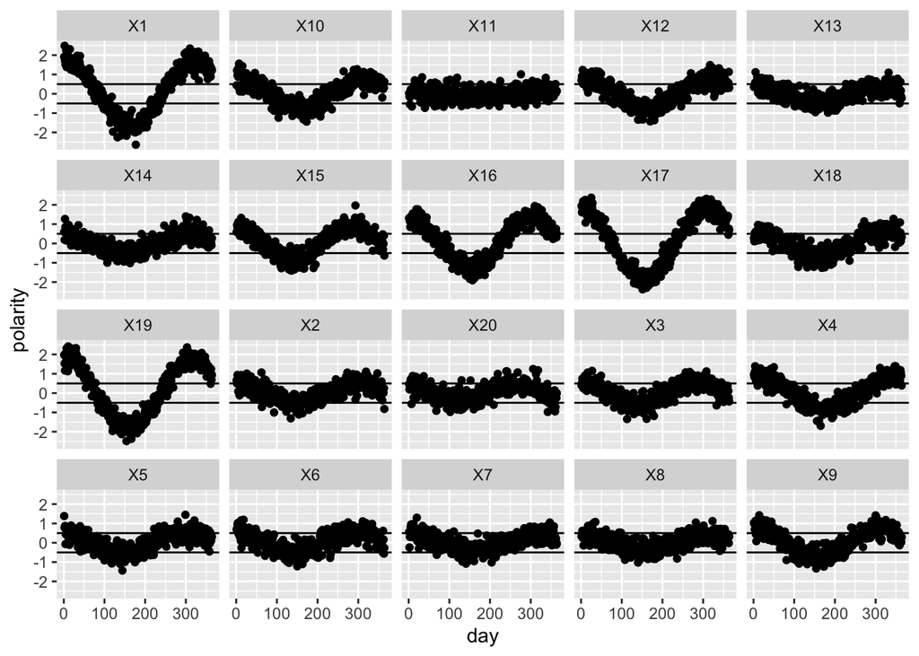

```r
# Simulate physical activity level (daily)
pday <- seq(from = 1, to = 364, by = 1) # number of days of observation
duration <- 300
b <- 2*pi/duration
n <- 20 # sample size

pp <- rnorm(n, b, 0.001) # different period for each ind
ps <- rnorm(n, duration/4, 0.01) # different shift of episode for each ind
pa <- rnorm(n, 1, 0.5)

phys <- matrix(nrow = length(pday), ncol = n)
for (i in 1:ncol(phys)) {
 phys[,i] <- pa[i]*sin(pp[i]*(pday + ps[i])) + rnorm(length(pday), 0, 0.3) # add noise
}
phys.df <- data.frame(day = pday, phys, type = "phys") %>% pivot_longer(cols = (-c(day, type)), names_to = "ind", values_to = "polarity")

ggplot(phys.df, aes(x = day, y = polarity)) + geom_point() +
  facet_wrap(~ ind) +
  geom_hline(yintercept=-0.5) + geom_hline(yintercept=0.5)
```

### 3.1.2 Simulate mood (weekly)

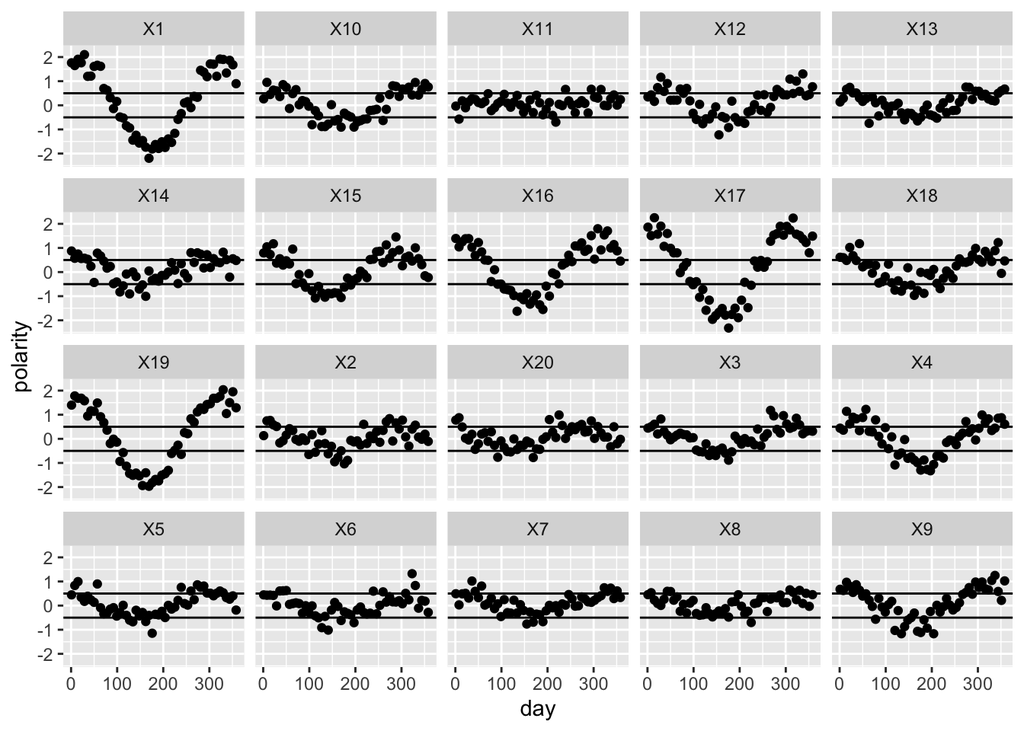

```r
# Simulate mood diary (weekly)
mday <- seq(from = 1, to = 364, by = 7) # number of days of observation
duration <- 300
b <- 2*pi/duration
n <- 20 # sample size
lag <- -7

# Assume that the relationship between activity and mood for each individual has
# - similar period
# - similar lag (specified as 7 days here)
mp <- NULL
ms <- NULL
ma <- NULL
for (i in 1:n) {
  mp <- c(mp, rnorm(1, pp[i], 0.0001))
  ms <- c(ms, rnorm(1, ps[i] + lag, 0.0001))
  ma <- c(ma, rnorm(1, pa[i], 0.0001))
}

mood <- matrix(nrow = length(mday), ncol = n)
for (i in 1:ncol(mood)) {
 mood[,i] <- ma[i]*sin(mp[i]*(mday + ms[i])) + rnorm(length(mday), 0, 0.3) # add noise
}
mood.df <- data.frame(day = mday, mood, type = "mood") %>% pivot_longer(cols = (-c(day, type)), names_to = "ind", values_to = "polarity")

ggplot(mood.df, aes(x = day, y = polarity)) + geom_point() +
  facet_wrap(~ ind) +
  geom_hline(yintercept=-0.5) + geom_hline(yintercept=0.5)
```

### 3.1.3 Clinical (monthly)

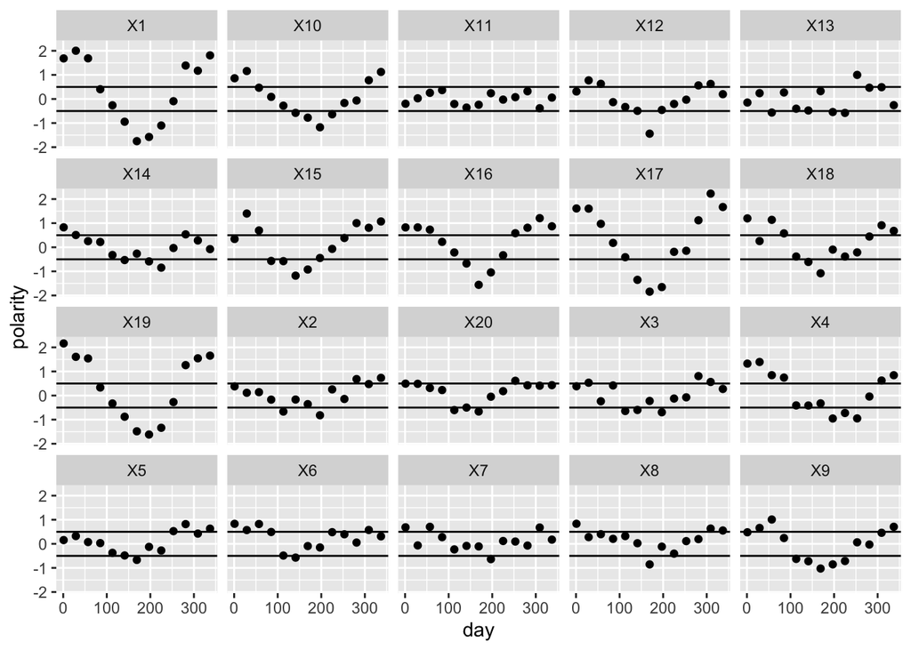

```r
# Simulate clinical (monthly)
cday <- seq(from = 1, to = 364, by = 28) # number of days of observation
duration <- 300
b <- 2*pi/duration
n <- 20 # sample size
lag <- -14

# Assume that the relationship between activity and clinical detection for each individual has
# - similar period
# - similar lag (specified as 14 days here)
cp <- NULL
cs <- NULL
ca <- NULL
for (i in 1:n) {
  cp <- c(cp, rnorm(1, pp[i], 0.0001))
  cs <- c(cs, rnorm(1, ps[i] + lag, 0.0001))
  ca <- c(ca, rnorm(1, pa[i], 0.0001))
}

clin <- matrix(nrow = length(cday), ncol = n)
for (i in 1:ncol(clin)) {
 clin[,i] <- ca[i]*sin(cp[i]*(cday + cs[i])) + rnorm(length(cday), 0, 0.3) # add noise
}
clin.df <- data.frame(day = cday, clin, type = "clinical") %>% pivot_longer(cols = (-c(day, type)), names_to = "ind", values_to = "polarity")

ggplot(clin.df, aes(x = day, y = polarity)) + geom_point() +
  facet_wrap(~ ind) +
  geom_hline(yintercept=-0.5) + geom_hline(yintercept=0.5)
```

### 3.1.4 Visualise all data together

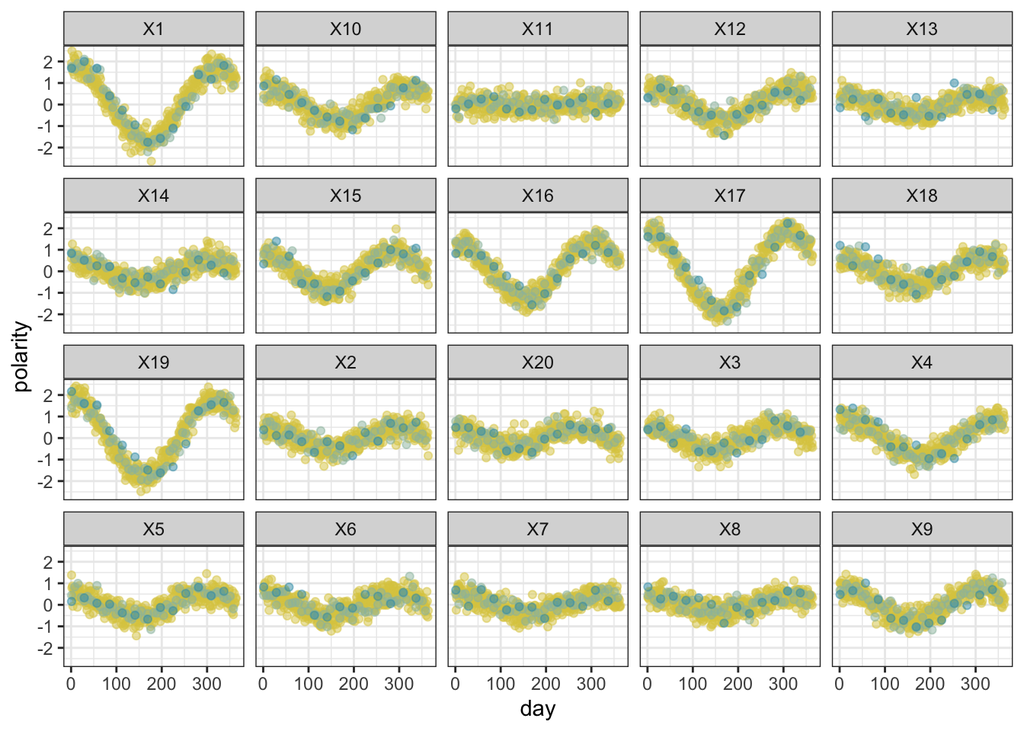

```r
sine.df <- full_join(phys.df, mood.df) %>% full_join(., clin.df)
ggplot(sine.df, aes(x = day, y = polarity, colour = type)) +
  geom_point(alpha = 0.5) +
  scale_colour_manual(values = pal) +
  theme_bw() + theme(legend.position = "none") +
  facet_wrap(~ ind)
```

## 3.2 Extensions to consider

library(phonTools) # for sinc() function library(splines) library(broom) library(ggformula)

# 4 Analysis

## 4.1 Granger causality test

Questions:

- How to determine good number of lags?
- How to apply over many people?

To read in more depth: https://davegiles.blogspot.com/2011/04/testing-for-granger-causality.html

```r
gt.moodphys <- list()
gt.physmood <- list()

for (i in 1:n) {
  tmp <- rbind(phys.df %>% filter(ind == paste("X", i, sep = "")),
             mood.df %>% filter(ind == paste("X", i, sep = ""))) %>%
      pivot_wider(id_cols = "day", names_from = "type", values_from = "polarity")

  paged_table(tmp)

  gt.moodphys[[i]] <- grangertest(mood ~ phys, order = 3, data = tmp)
  gt.physmood[[i]] <- grangertest(phys ~ mood, order = 3, data = tmp)

}

gt.moodphys.tbl <- lapply(gt.moodphys, tbl_regression)
gt.physmood.tbl <- lapply(gt.physmood, tbl_regression)

tbl_merge(tbls = gt.moodphys.tbl, tab_spanner = paste("X", seq(1, n, 1), sep = ""))
```

| **Characteristic** | X1 **p-value** | X2 **p-value** | X3 **p-value** | X4 **p-value** | X5 **p-value** | X6 **p-value** | X7 **p-value** | X8 **p-value** | X9 **p-value** | X10 **p-value** | X11 **p-value** | X12 **p-value** | X13 **p-value** | X14 **p-value** | X15 **p-value** | X16 **p-value** | X17 **p-value** | X18 **p-value** | X19 **p-value** | X20 **p-value** |
| --- | --- | --- | --- | --- | --- | --- | --- | --- | --- | --- | --- | --- | --- | --- | --- | --- | --- | --- | --- | --- |
| Model 1: mood ~ Lags(mood, 1:3) + Lags(phys, 1:3) |  |  |  |  |  |  |  |  |  |  |  |  |  |  |  |  |  |  |  |  |
| Model 2: mood ~ Lags(mood, 1:3) | <0.001 | 0.064 | 0.001 | 0.004 | 0.008 | 0.005 | 0.005 | 0.021 | 0.003 | 0.002 | 0.4 | <0.001 | 0.4 | 0.2 | 0.042 | <0.001 | <0.001 | 0.7 | <0.001 | 0.7 |

```r
tbl_merge(tbls = gt.physmood.tbl, tab_spanner = paste("X", seq(1, n, 1), sep = ""))
```

| **Characteristic** | X1 **p-value** | X2 **p-value** | X3 **p-value** | X4 **p-value** | X5 **p-value** | X6 **p-value** | X7 **p-value** | X8 **p-value** | X9 **p-value** | X10 **p-value** | X11 **p-value** | X12 **p-value** | X13 **p-value** | X14 **p-value** | X15 **p-value** | X16 **p-value** | X17 **p-value** | X18 **p-value** | X19 **p-value** | X20 **p-value** |
| --- | --- | --- | --- | --- | --- | --- | --- | --- | --- | --- | --- | --- | --- | --- | --- | --- | --- | --- | --- | --- |
| Model 1: phys ~ Lags(phys, 1:3) + Lags(mood, 1:3) |  |  |  |  |  |  |  |  |  |  |  |  |  |  |  |  |  |  |  |  |
| Model 2: phys ~ Lags(phys, 1:3) | 0.13 | 0.2 | 0.4 | 0.002 | 0.043 | 0.6 | 0.3 | 0.10 | 0.2 | 0.3 | 0.5 | 0.8 | 0.095 | 0.012 | 0.038 | 0.2 | 0.012 | 0.007 | 0.006 | 0.028 |

### 4.1.1 Plot p-values

False positive/negatives shown with:

- dotted line for p<0.05
- dashed line for Bonferroni correction
- Q1: true + for mood ~ phys / true - for phys ~ mood
- Q2: true + for mood ~ phys / false + for phys ~ mood
- Q3: false - for mood ~ phys / true - for phys ~ mood
- Q4: false - for mood ~ phys / false + for phys ~ mood

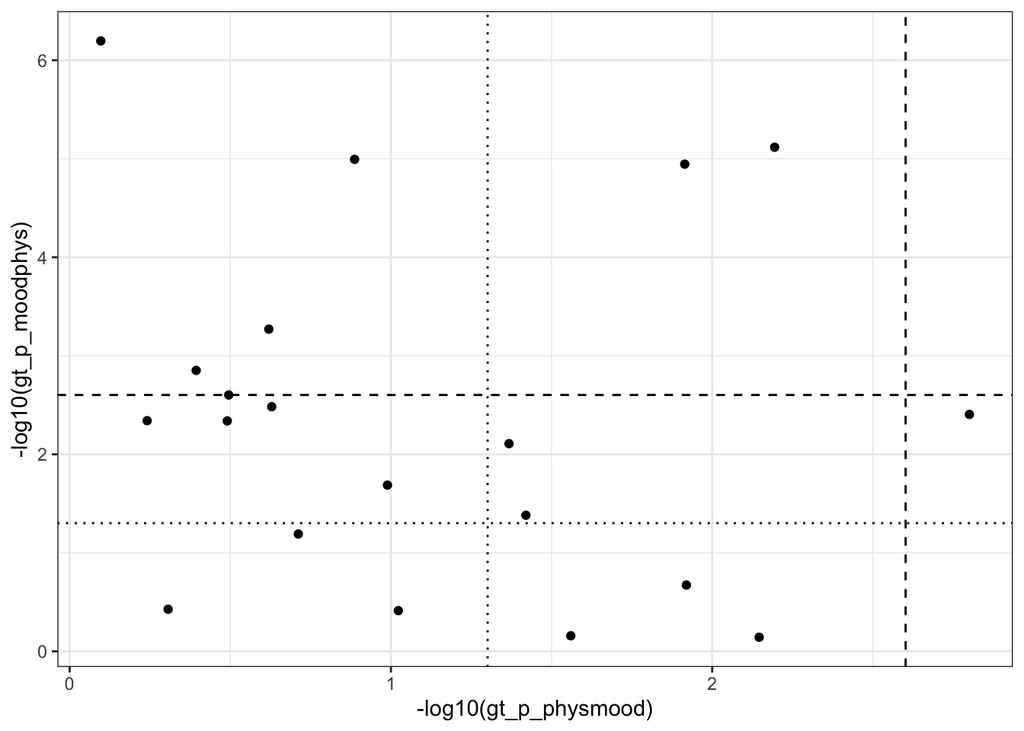

```r
gt.moodphys.p <- unlist(lapply(1:n, function(x) gt.moodphys[[x]]$`Pr(>F)`[2]))
gt.physmood.p <- unlist(lapply(1:n, function(x) gt.physmood[[x]]$`Pr(>F)`[2]))

gt.p.df <- data.frame(id = paste("X", seq(1, n, 1), sep = ""), gt_p_moodphys = gt.moodphys.p, gt_p_physmood = gt.physmood.p)

ggplot(gt.p.df, aes(x = -log10(gt_p_physmood), y = -log10(gt_p_moodphys))) +
  geom_point() +
  theme_bw() +
  geom_hline(yintercept = -log10(0.05), linetype = "dotted") +
  geom_hline(yintercept = -log10(0.05/n), linetype = "dashed") +
  geom_vline(xintercept = -log10(0.05), linetype = "dotted") +
  geom_vline(xintercept = -log10(0.05/n), linetype = "dashed")
```

## 4.2 Spline? Sine wave?

Not sure what I should use to flexibly fit a function (assuming that’s the right thing to do) …

Maybe try(?):

- fit some ?spline function for the monthly clinical data (“ground truth A”)
- fit some ?spline function for the weekly mood diary data (“ground truth B”)
- try and fit functions A and B with changeable left-shift for the wearables data and see if it picks up the lag time?

Limitations of this approach:

- don’t know in real data if the exact same trend is followed across datasets!
- might just be looking for any change preceding depression defined using ground truth A and ground truth B … ?Bayesian approach since prior is strong and n is small?

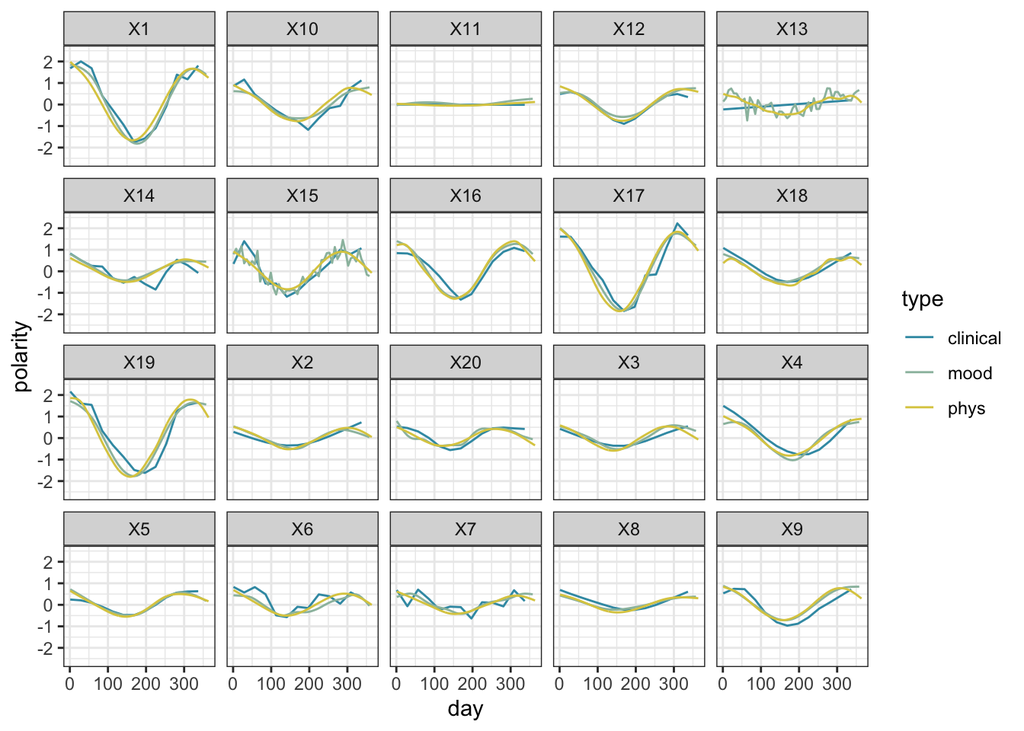

```r
# spline() ???

foo <- sine.df %>% filter(ind == "X1" & type == "phys")

tmp <- ggplot(sine.df, aes(x = day, y = polarity, colour = type)) +
  geom_point(alpha = 0.) +
  geom_spline() +
  scale_colour_manual(values = pal) +
  theme_bw() +
  facet_wrap(~ ind)
tmp
```

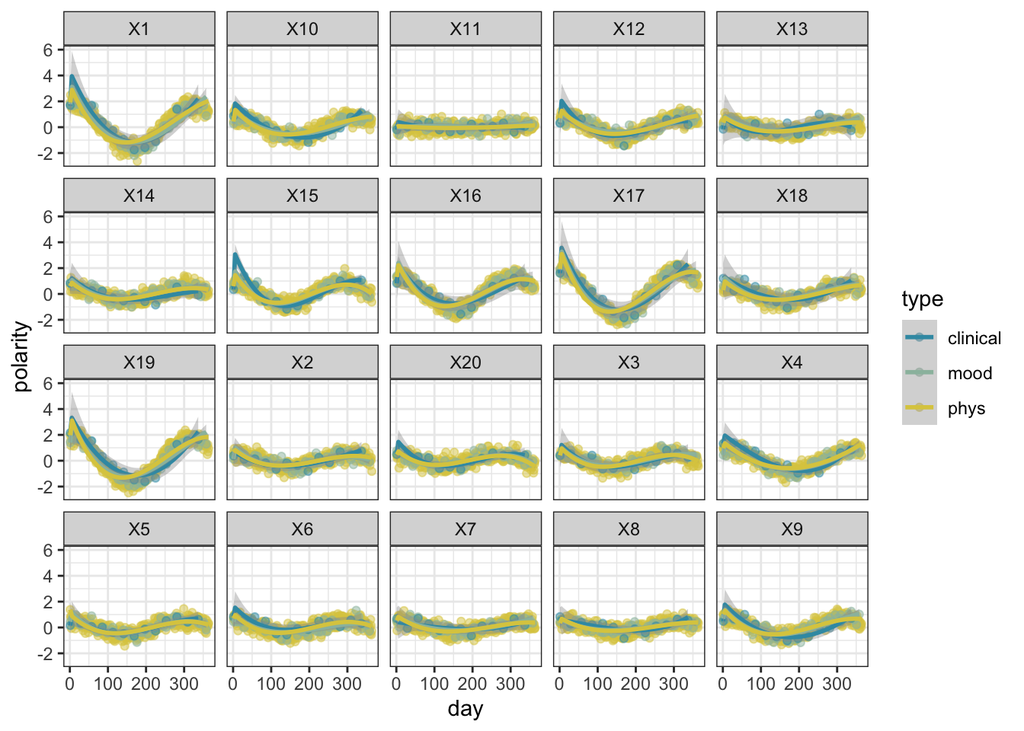

```r
tmp <- ggplot(sine.df, aes(x = day, y = polarity, colour = type)) +
  geom_point(alpha = 0.5) +
  geom_smooth(method = lm,
              formula = y ~ splines::bs(x, knots = 2)) +
  scale_colour_manual(values = pal) +
  theme_bw() +
  facet_wrap(~ ind)
tmp
```

# 5 (IGNORE): Extensions

- changing midline: https://math.libretexts.org/Bookshelves/Precalculus/Book%3A_Precalculus__An_Investigation_of_Functions_%28Lippman_and_Rasmussen%29/07%3A_Trigonometric_Equations_and_Identities/7.04%3A_Modeling_Changing_Amplitude_and_Midline
- dampened sine wave